# Pandas-Bootcamp-Part8

### GroupBy Transformations

```python
#groupby() + transform() for inplace transformation applied at sub-group level
```

transform() : Applies a transformation inplace

When it is combined with groupby() gives us access to a whole new array of transforms that could be applied at the subgroup level.

For example :

As Data Scientist or Analyst we are facing a task, to convert raw global_sales to within-genre standard scores

We need to convert the global sales data from the raw sales that we have in our 'games' dataframe.

```python
games.head()
```

|  | Name | Platform | Year | Genre | Publisher | NA_Sales | EU_Sales | JP_Sales | Other_Sales | Global_Sales |
| --- | --- | --- | --- | --- | --- | --- | --- | --- | --- | --- |
| 0 | Kinect Adventures! | X360 | 2010.0 | Misc | Microsoft Game Studios | 14.97 | 4.94 | 0.24 | 1.67 | 21.82 |
| 1 | Grand Theft Auto V | PS3 | 2013.0 | Action | Take-Two Interactive | 7.01 | 9.27 | 0.97 | 4.14 | 21.40 |
| 2 | Grand Theft Auto V | X360 | 2013.0 | Action | Take-Two Interactive | 9.63 | 5.31 | 0.06 | 1.38 | 16.38 |
| 3 | Call of Duty: Modern Warfare 3 | X360 | 2011.0 | Shooter | Activision | 9.03 | 4.28 | 0.13 | 1.32 | 14.76 |
| 4 | Call of Duty: Black Ops | X360 | 2010.0 | Shooter | Activision | 9.67 | 3.73 | 0.11 | 1.13 | 14.64 |

#### Standard score is nothing but Z-score

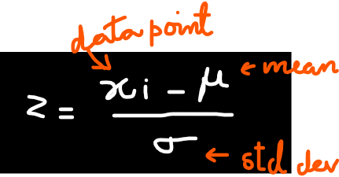

Z-Score : We take any given observation , subtract the Mean then divide by the standard Deviation and that gives us the sense of how high or low relative to its sample , any given observation is.

A Z-score is a numerical measurement that describes a value's relationship to the mean of a group of values

The Z-score, or standard score, is the number of standard deviations a given data point lies above or below the mean.

Z score or standard score describes a value's relationship to the mean of a group of values.

A z score can be defined as a measure of the number of standard deviations by which a score is below or above the mean of a distribution.

```python
#Lets say that a single game sold at 5 M
game_sale = 5
#This game gave a Genre Avg
game_genre_avg = 0.5
game_genre_std = 0.1
```

```python
#The Standard Score for this game is 45. So, this game is an Outeperformer.
Z_Score  = (game_sale - game_genre_avg)/game_genre_std
```

```python
Z_Score
```

```
45.0
```

- So, we tansformed the raw sales (game_sale = 5), to 45 , which is a relatively within group outperformance of this game. It has nothing to do with 0.5 , it has everything to do with the relationship between all three :{game_sale = 5 ,game_genre_avg = 0.5 , game_genre_std = 0.1}

```python
games_relative = games.loc[: , ['Name' , 'Genre' , 'Platform' , 'Global_Sales']]
```

```python
games_relative.head(2)
```

|  | Name | Genre | Platform | Global_Sales |
| --- | --- | --- | --- | --- |
| 0 | Kinect Adventures! | Misc | X360 | 21.82 |
| 1 | Grand Theft Auto V | Action | PS3 | 21.40 |

```python
games_relative.set_index(['Name' , 'Platform'])
```

| Name | Platform | Genre | Global_Sales |
| --- | --- | --- | --- |
| Kinect Adventures! | X360 | Misc | 21.82 |
| Grand Theft Auto V | PS3 | Action | 21.40 |
|  | X360 | Action | 16.38 |
| Call of Duty: Modern Warfare 3 | X360 | Shooter | 14.76 |
| Call of Duty: Black Ops | X360 | Shooter | 14.64 |
| ... | ... | ... | ... |
| Bound By Flame | X360 | Role-Playing | 0.01 |
| Mighty No. 9 | XOne | Platform | 0.01 |
| Resident Evil 4 HD | XOne | Shooter | 0.01 |
| Farming 2017 - The Simulation | PS4 | Simulation | 0.01 |
| Rugby Challenge 3 | XOne | Sports | 0.01 |

3143 rows × 2 columns

```python
games_relative.set_index(['Name' , 'Platform']).groupby('Genre').transform(lambda x: (x - x.mean())/x.std())\
    .sort_values(by = 'Global_Sales' , ascending = False)
```

| Name | Platform | Global_Sales |
| --- | --- | --- |
| Grand Theft Auto V | PS3 | 13.831175 |
| Kinect Adventures! | X360 | 13.814162 |
| Grand Theft Auto V | X360 | 10.468663 |
| Gran Turismo 5 | PS3 | 9.159261 |
| Grand Theft Auto V | PS4 | 7.521441 |
| ... | ... | ... |
| Dragon Ball Z for Kinect | X360 | -0.872762 |
| Nitroplus Blasterz: Heroines Infinite Duel | PS3 | -0.872762 |
| Battle Fantasia | PS3 | -0.872762 |
| Sakigake!! Otokojuku - Nihon yo, Kore ga Otoko Dearu! | PS3 | -0.872762 |
| The Talos Principle | PS4 | -0.899346 |

3143 rows × 1 columns

- "Grand Theft Auto V" is consitently one of the ALL Time Best Sellers relative to its Genre across all gaming platforms
- So, thats the transformation with groupby
- Aggregation : One thing to remember is Aggregations reduce the dimensions of the dataframe

  ```
            because they aggregate or collapse one of the axis
  ```

- Filter : Include / Exclude records without changing the dimensions
- transform : Change the value in place without altering the shape

### groupby() + apply()

```python
#We take the slice of data
ps3 = games.loc[games.Platform == 'PS3', ['Name' , 'Platform','Genre' , 'EU_Sales' , 'Global_Sales']]
```

```python
ps3
```

|  | Name | Platform | Genre | EU_Sales | Global_Sales |
| --- | --- | --- | --- | --- | --- |
| 1 | Grand Theft Auto V | PS3 | Action | 9.27 | 21.40 |
| 6 | Call of Duty: Black Ops II | PS3 | Shooter | 5.88 | 14.03 |
| 9 | Call of Duty: Modern Warfare 3 | PS3 | Shooter | 5.82 | 13.46 |
| 10 | Call of Duty: Black Ops | PS3 | Shooter | 4.44 | 12.73 |
| 14 | Gran Turismo 5 | PS3 | Racing | 4.88 | 10.77 |
| ... | ... | ... | ... | ... | ... |
| 3124 | Hyperdimension Neptunia mk2 | PS3 | Action | 0.01 | 0.01 |
| 3125 | Shin Koihime Musou: Otome Taisen * Sangokushi ... | PS3 | Adventure | 0.00 | 0.01 |
| 3129 | Muv-Luv Alternative | PS3 | Simulation | 0.00 | 0.01 |
| 3132 | Akatsuki no Goei Trinity | PS3 | Adventure | 0.00 | 0.01 |
| 3136 | Battle Fantasia | PS3 | Fighting | 0.00 | 0.01 |

1329 rows × 5 columns

```python
ps3.groupby('Genre').EU_Sales.sum()
```

```
Genre
Action          110.62
Adventure         8.13
Fighting         14.69
Misc             16.92
Platform         11.38
Puzzle            0.05
Racing           33.86
Role-Playing     19.79
Shooter          75.14
Simulation        3.78
Sports           48.02
Strategy          1.33
Name: EU_Sales, dtype: float64
```

```python
ps3.groupby('Genre').apply(lambda sg: 'solid' if sg.EU_Sales.sum() > 50 else 'weak')
```

```
Genre
Action          solid
Adventure        weak
Fighting         weak
Misc             weak
Platform         weak
Puzzle           weak
Racing           weak
Role-Playing     weak
Shooter         solid
Simulation       weak
Sports           weak
Strategy         weak
dtype: object
```

Lets say , we are not happy with only knowing the level of Sales, instead we also want toget the feel for how variable these sales are.

```python
#Lets go and create a function for it.
```

Before that lets understand the Coefficient of variation: Its the ratio of Std dev and the mean

For "variability" we are using a metric called "Coeff of Variation" , also known as the relative Std deviation.

- "volatile" if the coeff of variation is greater than 2 , else "Steady"
- this below function returns a tuple of strings
- return(variability , level + ' sales')

```python
def sales_detail(sg):
    level = 'solid' if sg.EU_Sales.sum() > 50 else 'weak'
    variability = 'volatile' if sg.EU_Sales.std()/sg.EU_Sales.mean() > 2  else 'steady'
    return(variability , level + ' sales')
```

```python
ps3.groupby('Genre').apply(sales_detail)
```

```
Genre
Action          (volatile, solid sales)
Adventure        (volatile, weak sales)
Fighting           (steady, weak sales)
Misc               (steady, weak sales)
Platform           (steady, weak sales)
Puzzle             (steady, weak sales)
Racing             (steady, weak sales)
Role-Playing     (volatile, weak sales)
Shooter           (steady, solid sales)
Simulation         (steady, weak sales)
Sports           (volatile, weak sales)
Strategy           (steady, weak sales)
dtype: object
```

- We see that , by the criteria that we set , most Genre's in this sample have steady-weak sales and only one category has "steady solid sales" , that means , the Average game in the Genre brings in the lot of money. And also the variability across 'games' within the 'Genre' is also low.

### Skill Challenge

#### Starting with the games dataframe , calculate the Total Global sales across for each year (Year) across all records. what are the Top 3 years by aggregate global sales.

```python
games.head(1)
```

|  | Name | Platform | Year | Genre | Publisher | NA_Sales | EU_Sales | JP_Sales | Other_Sales | Global_Sales |
| --- | --- | --- | --- | --- | --- | --- | --- | --- | --- | --- |
| 0 | Kinect Adventures! | X360 | 2010.0 | Misc | Microsoft Game Studios | 14.97 | 4.94 | 0.24 | 1.67 | 21.82 |

```python
games.groupby('Year').sum().sort_values(by = 'Global_Sales' , ascending = False)
```

| Year | NA_Sales | EU_Sales | JP_Sales | Other_Sales | Global_Sales |
| --- | --- | --- | --- | --- | --- |
| 2010.0 | 168.13 | 99.57 | 11.98 | 35.65 | 315.47 |
| 2011.0 | 151.50 | 101.96 | 15.88 | 35.11 | 304.49 |
| 2008.0 | 139.62 | 78.35 | 7.72 | 29.77 | 255.45 |
| 2009.0 | 136.60 | 76.34 | 10.98 | 29.35 | 253.19 |
| 2013.0 | 116.33 | 89.50 | 13.50 | 31.02 | 250.36 |
| 2014.0 | 100.71 | 96.20 | 9.37 | 32.39 | 238.57 |
| 2012.0 | 98.12 | 73.72 | 13.00 | 25.39 | 210.37 |
| 2015.0 | 86.92 | 80.61 | 10.03 | 26.58 | 204.23 |
| 2007.0 | 95.10 | 49.17 | 5.74 | 19.65 | 169.65 |
| 2006.0 | 43.99 | 18.59 | 2.27 | 8.15 | 72.95 |
| 2016.0 | 19.31 | 23.31 | 5.37 | 7.07 | 55.04 |
| 2005.0 | 6.89 | 0.51 | 0.28 | 0.63 | 8.32 |
| 2017.0 | 0.00 | 0.00 | 0.03 | 0.00 | 0.03 |

```python
games.groupby('Year').sum().sort_values(by = 'Global_Sales' , ascending = False).head(3)
```

| Year | NA_Sales | EU_Sales | JP_Sales | Other_Sales | Global_Sales |
| --- | --- | --- | --- | --- | --- |
| 2010.0 | 168.13 | 99.57 | 11.98 | 35.65 | 315.47 |
| 2011.0 | 151.50 | 101.96 | 15.88 | 35.11 | 304.49 |
| 2008.0 | 139.62 | 78.35 | 7.72 | 29.77 | 255.45 |

- 2010 , 2011 and 2008 are the top 3 years by aggregate Global sales

### OR

```python
games.groupby('Year').sum()['Global_Sales'].nlargest(3)
```

```
Year
2010.0    315.47
2011.0    304.49
2008.0    255.45
Name: Global_Sales, dtype: float64
```

#### In the games dataframe , what Genre , in what Year , in what Platform sold the most in Europe (EU_Sales)?

```python
games.groupby(['Genre' , 'Platform' , 'Year']).sum().sort_values(by = 'EU_Sales' , ascending = False)
```

| Genre | Platform | Year | NA_Sales | EU_Sales | JP_Sales | Other_Sales | Global_Sales |
| --- | --- | --- | --- | --- | --- | --- | --- |
| Action | PS3 | 2013.0 | 18.47 | 21.72 | 4.95 | 9.34 | 54.44 |
|  | PS4 | 2014.0 | 14.68 | 19.18 | 1.63 | 7.36 | 42.84 |
|  | PS3 | 2012.0 | 16.27 | 17.37 | 4.35 | 7.46 | 45.45 |
|  |  | 2011.0 | 16.66 | 16.49 | 5.05 | 6.37 | 44.59 |
| Shooter | PS3 | 2011.0 | 16.83 | 15.98 | 1.88 | 5.59 | 40.25 |
| ... | ... | ... | ... | ... | ... | ... | ... |
| Strategy | PS4 | 2014.0 | 0.03 | 0.00 | 0.06 | 0.01 | 0.10 |
| Puzzle | PS3 | 2014.0 | 0.00 | 0.00 | 0.04 | 0.00 | 0.04 |
| Strategy | PS3 | 2014.0 | 0.00 | 0.00 | 0.06 | 0.00 | 0.06 |
| Puzzle | X360 | 2006.0 | 0.04 | 0.00 | 0.00 | 0.00 | 0.04 |
| Platform | X360 | 2015.0 | 0.08 | 0.00 | 0.00 | 0.01 | 0.09 |

307 rows × 5 columns

### OR

```python
games.groupby(['Genre' , 'Platform' , 'Year']).sum()['EU_Sales'].nlargest(1)
```

```
Genre   Platform  Year
Action  PS3       2013.0    21.72
Name: EU_Sales, dtype: float64
```

https://www.udemy.com/course/the-ultimate-pandas-bootcamp-advanced-python-data-analysis/learn/lecture/19297608#questions/13647656

#### Find all the names in the games dataset , whose Genre in their respective Platform sold more in Japan (JP_Sales) than in Europe (EU_Sales)

```python
games.groupby(['Genre' , 'Platform']).sum()[['JP_Sales', 'EU_Sales']].sort_values(by='EU_Sales' , ascending = False)
```

| Genre | Platform | JP_Sales | EU_Sales |
| --- | --- | --- | --- |
| Action | PS3 | 29.59 | 110.62 |
|  | X360 | 2.77 | 76.81 |
| Shooter | X360 | 3.10 | 76.59 |
|  | PS3 | 8.81 | 75.14 |
| Sports | PS3 | 7.90 | 48.02 |
| Action | PS4 | 5.41 | 38.19 |
| Sports | X360 | 0.41 | 37.50 |
| Racing | PS3 | 3.13 | 33.86 |
| Shooter | PS4 | 2.33 | 33.15 |
| Racing | X360 | 0.52 | 25.90 |
| Sports | PS4 | 0.92 | 22.88 |
| Misc | X360 | 0.45 | 20.54 |
| Role-Playing | PS3 | 16.82 | 19.79 |
|  | X360 | 2.61 | 18.56 |
| Misc | PS3 | 1.38 | 16.92 |
| Shooter | XOne | 0.16 | 15.27 |
| Fighting | PS3 | 6.54 | 14.69 |
| Action | XOne | 0.05 | 11.47 |
| Platform | PS3 | 0.61 | 11.38 |
| Role-Playing | PS4 | 3.23 | 10.55 |
| Fighting | X360 | 0.96 | 8.92 |
| Adventure | PS3 | 2.68 | 8.13 |
| Sports | XOne | 0.02 | 7.67 |
| Racing | PS4 | 0.26 | 7.12 |
| Adventure | X360 | 0.61 | 4.86 |
| Platform | X360 | 0.02 | 4.19 |
| Racing | XOne | 0.05 | 4.16 |
| Simulation | X360 | 0.70 | 4.03 |
|  | PS3 | 1.27 | 3.78 |
| Platform | PS4 | 0.49 | 3.32 |
| Role-Playing | XOne | 0.01 | 3.06 |
| Misc | PS4 | 0.35 | 3.03 |
| Fighting | PS4 | 0.70 | 2.73 |
| Strategy | X360 | 0.13 | 2.64 |
| Adventure | PS4 | 0.38 | 2.19 |
| Misc | XOne | 0.01 | 1.82 |
| Strategy | PS3 | 1.16 | 1.33 |
| Adventure | XOne | 0.03 | 1.08 |
| Fighting | XOne | 0.01 | 0.52 |
| Simulation | PS4 | 0.16 | 0.37 |
| Platform | XOne | 0.00 | 0.29 |
| Simulation | XOne | 0.00 | 0.21 |
| Strategy | PS4 | 0.07 | 0.15 |
|  | XOne | 0.00 | 0.10 |
| Puzzle | PS3 | 0.10 | 0.05 |
|  | X360 | 0.15 | 0.04 |
|  | PS4 | 0.00 | 0.02 |

```python
JP = games.groupby(['Genre' , 'Platform']).sum()[['JP_Sales', 'EU_Sales']].sort_values(by='EU_Sales' , ascending = False)
```

```python
JP.loc[JP.JP_Sales > JP.EU_Sales]
```

| Genre | Platform | JP_Sales | EU_Sales |
| --- | --- | --- | --- |
| Puzzle | PS3 | 0.10 | 0.05 |
|  | X360 | 0.15 | 0.04 |

### OR

```python
games.groupby(['Platform' , 'Genre']).filter(lambda x: x['JP_Sales'].sum() > x.EU_Sales.sum())
```

|  | Name | Platform | Year | Genre | Publisher | NA_Sales | EU_Sales | JP_Sales | Other_Sales | Global_Sales |
| --- | --- | --- | --- | --- | --- | --- | --- | --- | --- | --- |
| 1246 | Katamari Forever | PS3 | 2009.0 | Puzzle | Namco Bandai Games | 0.26 | 0.05 | 0.06 | 0.04 | 0.42 |
| 1440 | Beautiful Katamari | X360 | 2007.0 | Puzzle | Namco Bandai Games | 0.14 | 0.02 | 0.15 | 0.02 | 0.32 |
| 2117 | Bejeweled 3 | PS3 | NaN | Puzzle | Unknown | 0.13 | 0.00 | 0.00 | 0.01 | 0.14 |
| 2132 | Bejeweled 3 | X360 | NaN | Puzzle | Unknown | 0.13 | 0.00 | 0.00 | 0.01 | 0.14 |
| 2214 | Are You Smarter than a 5th Grader? Game Time | X360 | 2009.0 | Puzzle | THQ | 0.12 | 0.00 | 0.00 | 0.01 | 0.12 |
| 2318 | Tetris Evolution | X360 | 2007.0 | Puzzle | THQ | 0.08 | 0.02 | 0.00 | 0.01 | 0.11 |
| 2497 | Qubed | X360 | 2009.0 | Puzzle | Atari | 0.07 | 0.00 | 0.00 | 0.01 | 0.08 |
| 2744 | Puyo Puyo Tetris | PS3 | 2014.0 | Puzzle | Sega | 0.00 | 0.00 | 0.04 | 0.00 | 0.04 |
| 2767 | PopCap Arcade Vol 1 | X360 | 2007.0 | Puzzle | PopCap Games | 0.04 | 0.00 | 0.00 | 0.00 | 0.04 |
| 2787 | Bomberman: Act Zero | X360 | 2006.0 | Puzzle | Konami Digital Entertainment | 0.04 | 0.00 | 0.00 | 0.00 | 0.04 |

🧡❤💛💚💙💜🧡❤💛💚💙💜🧡❤💛💚💙💜🧡❤💛💚💙💜🧡❤💛💚💙💜🧡❤💛💚💙💜🧡❤💛💚💙💜🧡❤💛💚💙💜🧡❤💛